# INLA 3

Lenin Rafael Riera Segura

Created: 12-04-2024. Last modified: 13-04-2024.

```css
body .main-container {
  max-width: 100% !important;
  width: 100% !important;
}
body {
  max-width: 100% !important;
}

body, td {
   font-size: 16px;
}
code.r{
  font-size: 14px;
}
pre {
  font-size: 14px
}
```

```r
knitr::opts_chunk$set(message = FALSE,
                      warning = FALSE,
                      echo = TRUE,
                      include = TRUE,
                      fig.align = "center",
                      out.width = "100%"
                      )
set.seed(1982)
```

```r
library(INLA)
```

Consider the AR(1) process

$$u_t = \rho u_{t-1}+\epsilon_t, \qquad \epsilon_t\sim\text{N}(0,1),\qquad
|\rho|<1$$

In this case, the precision matrix has main diagonal $1+\rho^2$ (except the first and last entries in the main diagonal, which are just 1) and sub- and super-diagonal with entries $-\rho$.

```r
precision.ar1 = function(n = 10, rho = 0.9){
  Q <- sparseMatrix(i = c(1:n, 1:(n-1), 2:n),
                    j = c(1:n, 2:n, 1:(n-1)),
                    x = c(rep(1 + rho^2, n),
                          rep(-rho, n-1),
                          rep(-rho, n-1)))
  Q[1,1] = Q[n,n] = 1
  return(Q)
}
precision.ar1()
```

```
## 10 x 10 sparse Matrix of class "dgCMatrix"
##
##  [1,]  1.0 -0.90  .     .     .     .     .     .     .     .
##  [2,] -0.9  1.81 -0.90  .     .     .     .     .     .     .
##  [3,]  .   -0.90  1.81 -0.90  .     .     .     .     .     .
##  [4,]  .    .    -0.90  1.81 -0.90  .     .     .     .     .
##  [5,]  .    .     .    -0.90  1.81 -0.90  .     .     .     .
##  [6,]  .    .     .     .    -0.90  1.81 -0.90  .     .     .
##  [7,]  .    .     .     .     .    -0.90  1.81 -0.90  .     .
##  [8,]  .    .     .     .     .     .    -0.90  1.81 -0.90  .
##  [9,]  .    .     .     .     .     .     .    -0.90  1.81 -0.9
## [10,]  .    .     .     .     .     .     .     .    -0.90  1.0
```

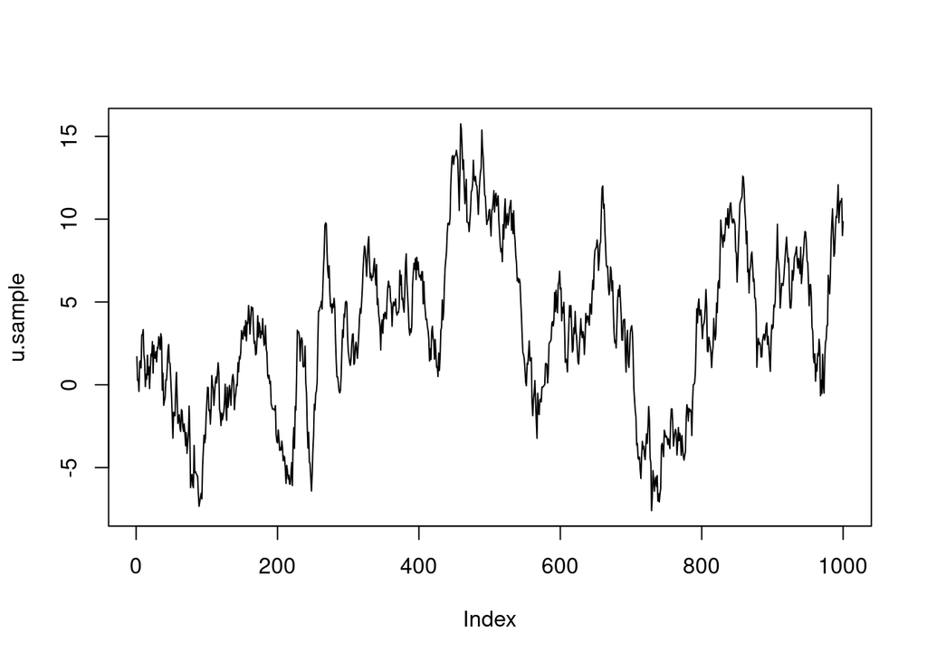

```r
Q = precision.ar1(1000, 0.99)
L = chol(Q)
set.seed(2017)
z.sample = rnorm(nrow(Q))
u.sample = solve(L, z.sample)
plot(u.sample, type="l")
```

## 0.1 Section 2

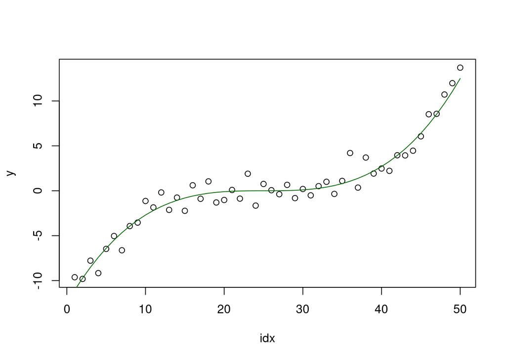

```r
set.seed(2017)
n = 50
idx = 1:n
fun = 100*((idx-n/2)/n)^3
y = fun + rnorm(n, mean=0, sd=1)
plot(idx, y)
lines(fun, col="darkgreen")
```

## 0.2 Model

$$y_i = x_i + \epsilon_i, \qquad \epsilon_i\sim\text{N}(0,\tau^{-1})$$

$$x_i -2x_{i-1}+x_{i-2}\sim\text{N}(0,\theta^{-1})$$
$$\pi(\mathbf{x}|\theta) \propto
\theta^{(n-2)/2}\exp\left(\dfrac{\theta}{2}\sum_{i=3}^n(x_i
-2x_{i-1}+x_{i-2})^2\right)$$

In INLA, $\log(\theta)$ has default prior loggamma with parameters 1 and 5e-05, meaning that $\theta$ has prior gamma with parameters 1 and 5e-05. That is,

$$\pi(\theta)\propto \theta^{a-1}\exp(-b\theta)$$

```r
df = data.frame(y=y, idx=idx)
df |> head() |> knitr::kable(caption = "Data")
```

Data

| y | idx |
| --- | --- |
| -9.624999 | 1 |
| -9.810892 | 2 |
| -7.779263 | 3 |
| -9.167405 | 4 |
| -6.469825 | 5 |
| -5.035295 | 6 |

```r
hyper1 = list(prec = list(initial = 0, fixed = T))
formula1 = y ~ -1 + f(idx, model = "rw2", hyper = hyper1)

res1 = inla(formula = formula1,
            family = "gaussian",
            data = df,
            control.family = list(hyper = hyper1))
```

```r
summary(res1)
```

```
## Time used:
##     Pre = 0.3, Running = 0.173, Post = 0.00889, Total = 0.482
## Random effects:
##   Name     Model
##     idx RW2 model
##
## Marginal log-Likelihood:  -102.24
##  is computed
## Posterior summaries for the linear predictor and the fitted values are computed
## (Posterior marginals needs also 'control.compute=list(return.marginals.predictor=TRUE)')
```

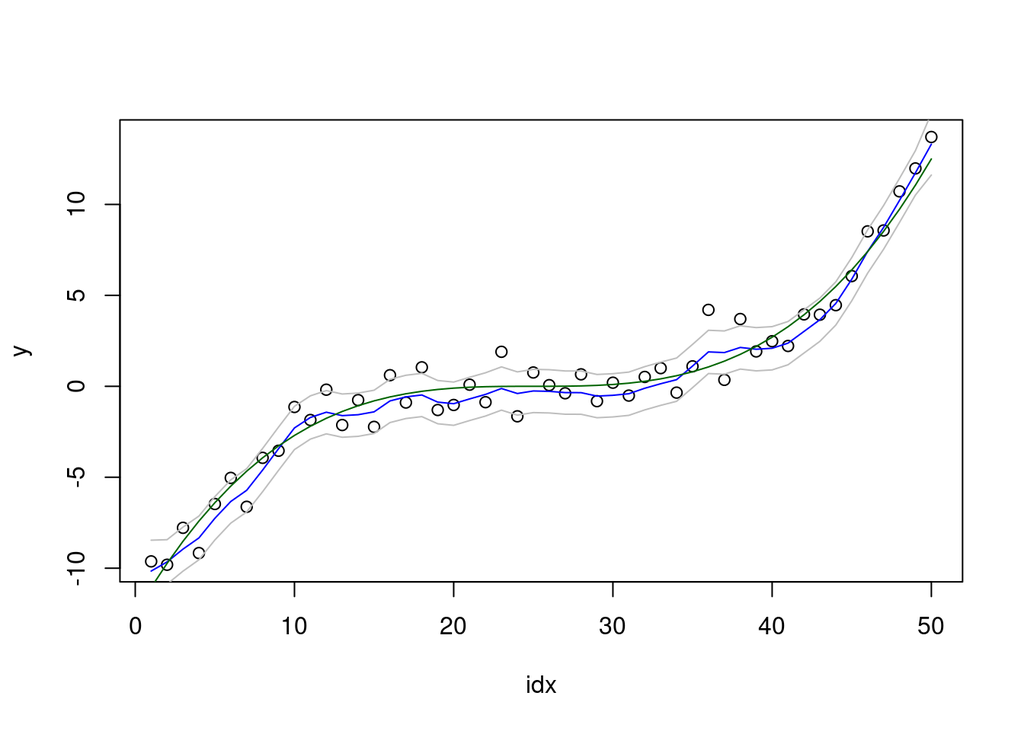

```r
local.plot.result = function(res) {
  plot(idx, y)
  lines(res$summary.random$idx$mean, col="blue")
  lines(res$summary.random$idx$`0.025quant`, col="grey")
  lines(res$summary.random$idx$`0.9`, col="grey")
  lines(fun, col="darkgreen")
}
local.plot.result(res1)
```

```r
formula2 = y ~ -1 + f(idx, model = "rw2")
res2 = inla(formula = formula2,
            family = "gaussian",
            data = df,
            control.family = list(hyper = hyper1),
            control.compute = list(config=TRUE))
summary(res2)
```

```
## Time used:
##     Pre = 0.132, Running = 0.139, Post = 0.0235, Total = 0.294
## Random effects:
##   Name     Model
##     idx RW2 model
##
## Model hyperparameters:
##                    mean    sd 0.025quant 0.5quant 0.975quant  mode
## Precision for idx 40.86 23.50      11.00    35.72     100.39 26.44
##
## Marginal log-Likelihood:  -96.41
##  is computed
## Posterior summaries for the linear predictor and the fitted values are computed
## (Posterior marginals needs also 'control.compute=list(return.marginals.predictor=TRUE)')
```

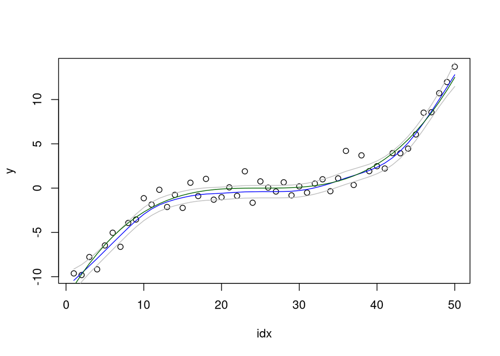

```r
local.plot.result(res2)
```

```r
res3 = inla(formula2,
            family = "gaussian",
            data = df)
summary(res3)
```

```
## Time used:
##     Pre = 0.152, Running = 0.153, Post = 0.00926, Total = 0.314
## Random effects:
##   Name     Model
##     idx RW2 model
##
## Model hyperparameters:
##                                           mean     sd 0.025quant 0.5quant
## Precision for the Gaussian observations  0.857  0.187      0.542     0.84
## Precision for idx                       44.235 27.328     11.687    37.76
##                                         0.975quant   mode
## Precision for the Gaussian observations       1.27  0.808
## Precision for idx                           114.80 27.079
##
## Marginal log-Likelihood:  -106.61
##  is computed
## Posterior summaries for the linear predictor and the fitted values are computed
## (Posterior marginals needs also 'control.compute=list(return.marginals.predictor=TRUE)')
```

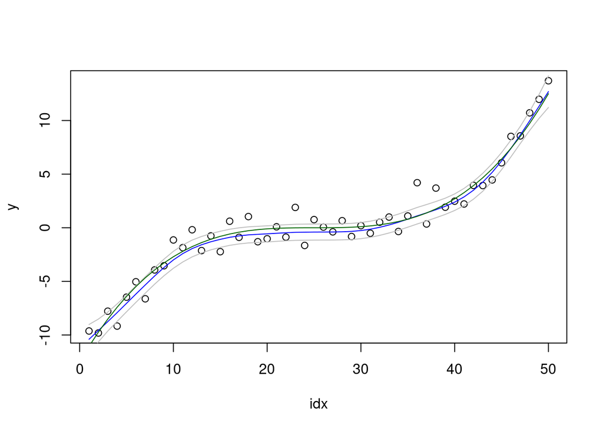

```r
local.plot.result(res3)
```

Remarks

- When we do `hyper1 = list(prec = list(initial = 0, fixed = T))` we are fixing the hyperparamaters. So no inference is obtained.
- When we do `hyper1 = list(prec = list(initial = 0, fixed = F))` we are not fixing the hyperparamaters. We are giving initial values apparently and so inference is obtained
- In the two previous cases we are not changing the prior.
- When we do not add any `hyper` parameter in the model, inference is obtained.
- If we actually want to change the prior, we do `hyper1 = list(theta1 = list(prior="pc.prec", param = c(1.99, 0.99)))` and inference is obtained.